# Suicide and self harm

2024-07-26

```r
data22.household = haven::read_dta("R://mhs2022d-g/MHS2022HHD.dta")
data22.person = haven::read_dta("R://mhs2022d-g/MHS2022SPL.dta")
data22 <- left_join(data22.household, data22.person)
original.labels = var_label(data22)

data = readRDS("data_suicide.rds")%>%
  filter(Age <=76)

imp_data = readRDS("imputed_data_suicide.rds")
imp_data = lapply(imp_data,function(x){x %>% filter(Age <= 76)})
```

# Survival analysis

## Censor at age 25

```r
surv.var = c("AFSUICAT","AFSTPLAN","AFSTTHGT","SHAGE1")

exposure = "Agegroup"

confounders = c("GenDiverse","Sexorient","ATSI","CALD")

for(var in surv.var){

# create survival data
surv.data = data %>%
  mutate(time = as.numeric(ifelse(!!sym(var)>=97|!!sym(var)==0, Age,!!sym(var))),
         status = ifelse(!!sym(var)>=97|!!sym(var)==0,0,1),
         status = ifelse(time > 25,0,status),
         time = ifelse(time > 25, 25, time)
         )

surv.data_imp =  lapply(imp_data, function(x){ x %>%
  mutate(time = as.numeric(ifelse(!!sym(var)>=97|!!sym(var)==0, Age,!!sym(var))),
         status = ifelse(!!sym(var)>=97|!!sym(var)==0,0,1),
         status = ifelse(time > 25,0,status),
         time = ifelse(time > 25, 25, time)
         )})

print(original.labels[[var]])
# fit coxph model
SurvivalTable(exposure,confounders,surv.data,imp_dta = surv.data_imp, MI = TRUE)

}
```

[1] “Age first attempted to take own life (all attempts)”

|  | chisq | df | p |
| --- | --- | --- | --- |
| Agegroup | 2.0923528 | 3 | 0.5534614 |
| GenDiverse | 12.7976343 | 2 | 0.0016635 |
| Sexorient | 1.4584275 | 1 | 0.2271805 |
| ATSI | 0.6170662 | 1 | 0.4321396 |
| CALD | 4.0633341 | 1 | 0.0438239 |
| GLOBAL | 18.8440003 | 8 | 0.0157166 |

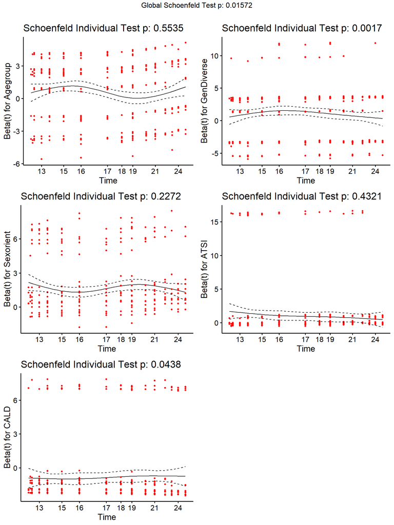

| variables | HR (95% CI) | p-value | exp(coef) | lower .95 | upper .95 |
| --- | --- | --- | --- | --- | --- |
| Agegroup16 to 25 | 2.94(2.00,4.33) | <0.001 | 2.939531 | 1.9963640 | 4.3282911 |
| Agegroup26 to 41 | 2.26(1.58,3.22) | <0.001 | 2.258971 | 1.5828604 | 3.2238783 |
| Agegroup42 to 57 | 1.31(0.89,1.93) | 0.178 | 1.308155 | 0.8854574 | 1.9326378 |
| GenDiverseFemale | 1.47(1.16,1.87) | 0.002 | 1.474145 | 1.1597490 | 1.8737707 |
| GenDiverseGender diverse | 2.41(1.38,4.22) | 0.002 | 2.410091 | 1.3761096 | 4.2209853 |
| SexorientGay/Lesbian/Bisexual | 5.15(3.86,6.87) | <0.001 | 5.148007 | 3.8595110 | 6.8666659 |
| ATSIAboriginal or Torres Strait Islander | 2.60(1.68,4.03) | <0.001 | 2.603822 | 1.6816023 | 4.0318021 |
| CALDYes | 0.49(0.35,0.68) | <0.001 | 0.487909 | 0.3482923 | 0.6834925 |

[1] “Age first time made a plan for taking own life”

|  | chisq | df | p |
| --- | --- | --- | --- |
| Agegroup | 3.3932357 | 3 | 0.3348753 |
| GenDiverse | 11.7117486 | 2 | 0.0028630 |
| Sexorient | 1.2092957 | 1 | 0.2714717 |
| ATSI | 4.3976031 | 1 | 0.0359895 |
| CALD | 0.0380958 | 1 | 0.8452510 |
| GLOBAL | 20.1203552 | 8 | 0.0098902 |

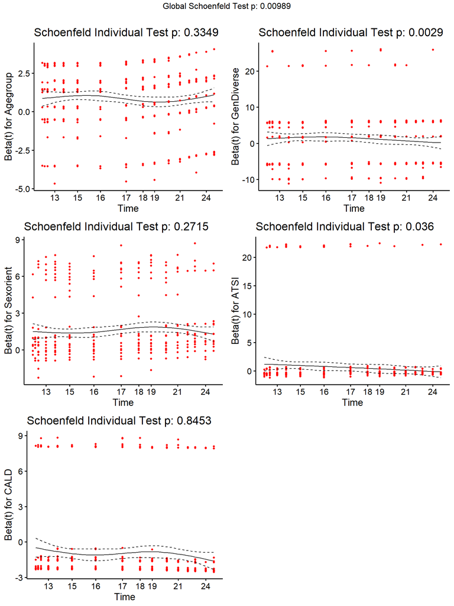

| variables | HR (95% CI) | p-value | exp(coef) | lower .95 | upper .95 |
| --- | --- | --- | --- | --- | --- |
| Agegroup16 to 25 | 5.61(3.77,8.36) | <0.001 | 5.6113984 | 3.7675966 | 8.3575273 |
| Agegroup26 to 41 | 3.59(2.46,5.22) | <0.001 | 3.5857797 | 2.4614717 | 5.2236294 |
| Agegroup42 to 57 | 2.19(1.45,3.31) | <0.001 | 2.1948336 | 1.4547964 | 3.3113189 |
| GenDiverseFemale | 1.21(0.99,1.49) | 0.069 | 1.2107899 | 0.9854704 | 1.4876269 |
| GenDiverseGender diverse | 1.67(0.97,2.88) | 0.066 | 1.6703171 | 0.9673443 | 2.8841429 |
| SexorientGay/Lesbian/Bisexual | 4.40(3.38,5.74) | <0.001 | 4.4027081 | 3.3771272 | 5.7397419 |
| ATSIAboriginal or Torres Strait Islander | 1.75(1.13,2.71) | 0.012 | 1.7501832 | 1.1302763 | 2.7100819 |
| CALDYes | 0.34(0.25,0.46) | <0.001 | 0.3416045 | 0.2535160 | 0.4603008 |

[1] “Age first time seriously thought about taking own life”

|  | chisq | df | p |
| --- | --- | --- | --- |
| Agegroup | 7.7599633 | 3 | 0.0512420 |
| GenDiverse | 14.8441096 | 2 | 0.0005979 |
| Sexorient | 11.8063085 | 1 | 0.0005903 |
| ATSI | 0.0038623 | 1 | 0.9504457 |
| CALD | 0.3293401 | 1 | 0.5660479 |
| GLOBAL | 29.1371394 | 8 | 0.0003000 |

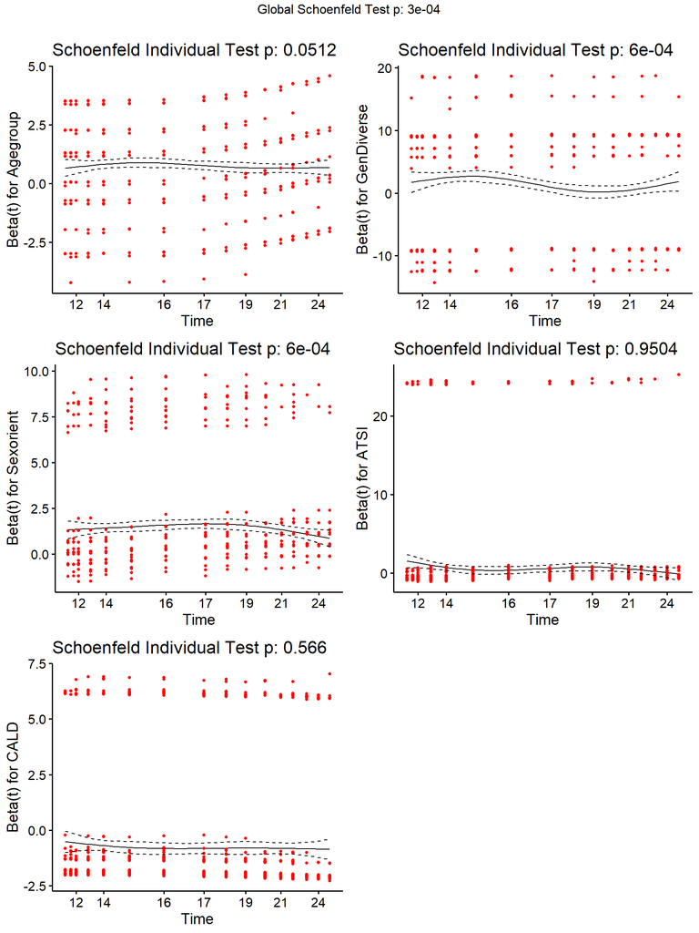

| variables | HR (95% CI) | p-value | exp(coef) | lower .95 | upper .95 |
| --- | --- | --- | --- | --- | --- |
| Agegroup16 to 25 | 4.44(3.55,5.57) | <0.001 | 4.444455 | 3.5453512 | 5.5715711 |
| Agegroup26 to 41 | 2.70(2.19,3.33) | <0.001 | 2.698661 | 2.1869666 | 3.3300791 |
| Agegroup42 to 57 | 1.67(1.31,2.12) | <0.001 | 1.665710 | 1.3110119 | 2.1163733 |
| GenDiverseFemale | 1.21(1.06,1.38) | 0.005 | 1.211164 | 1.0599319 | 1.3839751 |
| GenDiverseGender diverse | 1.43(1.01,2.04) | 0.045 | 1.434216 | 1.0078952 | 2.0408627 |
| SexorientGay/Lesbian/Bisexual | 3.76(3.14,4.51) | <0.001 | 3.760540 | 3.1377997 | 4.5068730 |
| ATSIAboriginal or Torres Strait Islander | 1.82(1.33,2.49) | <0.001 | 1.824006 | 1.3345170 | 2.4930357 |
| CALDYes | 0.47(0.39,0.57) | <0.001 | 0.470295 | 0.3896606 | 0.5676156 |

[1] “Age first time self-harmed”

|  | chisq | df | p |
| --- | --- | --- | --- |
| Agegroup | 2.0231719 | 3 | 0.5676112 |
| GenDiverse | 44.9486811 | 2 | 0.0000000 |
| Sexorient | 6.9427551 | 1 | 0.0084159 |
| ATSI | 0.1894351 | 1 | 0.6633872 |
| CALD | 5.9499168 | 1 | 0.0147180 |
| GLOBAL | 57.3240356 | 8 | 0.0000000 |

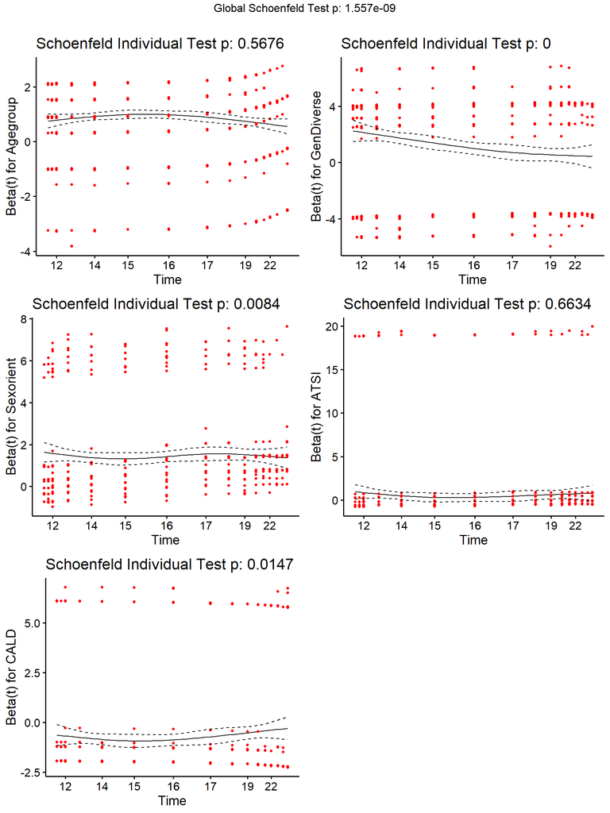

| variables | HR (95% CI) | p-value | exp(coef) | lower .95 | upper .95 |
| --- | --- | --- | --- | --- | --- |
| Agegroup16 to 25 | 18.44(11.77,28.88) | <0.001 | 18.4407784 | 11.7736891 | 28.8832416 |
| Agegroup26 to 41 | 9.55( 6.13,14.89) | <0.001 | 9.5524114 | 6.1275944 | 14.8914171 |
| Agegroup42 to 57 | 3.33( 2.05, 5.41) | <0.001 | 3.3271723 | 2.0477763 | 5.4059007 |
| GenDiverseFemale | 1.59( 1.35, 1.86) | <0.001 | 1.5868154 | 1.3524313 | 1.8618196 |
| GenDiverseGender diverse | 1.84( 1.22, 2.76) | 0.003 | 1.8369400 | 1.2246219 | 2.7554207 |
| SexorientGay/Lesbian/Bisexual | 3.98( 3.29, 4.82) | <0.001 | 3.9840031 | 3.2924563 | 4.8208023 |
| ATSIAboriginal or Torres Strait Islander | 1.97( 1.36, 2.85) | <0.001 | 1.9692449 | 1.3617143 | 2.8478263 |
| CALDYes | 0.45( 0.37, 0.56) | <0.001 | 0.4534995 | 0.3679443 | 0.5589483 |

# stratified by birth cohort, censor at 25

```r
surv.var = c("AFSUICAT","AFSTPLAN","AFSTTHGT","SHAGE1")
confounders = c("GenDiverse","Sexorient","ATSI","CALD",
               "CLOSEATT","LTHYNKR",
               "ICD_MHH","ICD_ANXH","ICD_AFFH","ICD_SUB",
               "PT13","PT22_1","sexually_assaulted_before19")
exposure = NULL

for(i in confounders)attr(data[[i]],'label') <- original.labels[[i]]

store.results = NULL
for(var in surv.var){
  for(agegroup in levels(data$Agegroup)){

# create survival data
surv.data = data %>%
  filter(Agegroup == agegroup) %>%
  mutate(time = as.numeric(ifelse(!!sym(var)>=97|!!sym(var)==0, AGEP,!!sym(var))),
         status = ifelse(!!sym(var)>=97|!!sym(var)==0,0,1),
         status = ifelse(time > 25,0,status),
         time = ifelse(time > 25, 25, time))

surv.data_imp =  lapply(imp_data, function(x){ x %>%
  filter(Agegroup == agegroup) %>%
  mutate(time = as.numeric(ifelse(!!sym(var)>=97|!!sym(var)==0, Age,!!sym(var))),
         status = ifelse(!!sym(var)>=97|!!sym(var)==0,0,1),
         status = ifelse(time > 25,0,status),
         time = ifelse(time > 25, 25, time)
         )})

print(original.labels[[var]])
print(agegroup)

# fit coxph model
store.results = rbind(store.results,
                      SurvivalTable(exposure,confounders,surv.data,imp_dta = surv.data_imp, MI = TRUE) %>%
  mutate(var = var,
         agegroup = agegroup))

}
}
```

[1] “Age first attempted to take own life (all attempts)” [1] “>57”

|  | chisq | df | p |
| --- | --- | --- | --- |
| GenDiverse | 1.0236585 | 2 | 0.5993981 |
| Sexorient | 0.3762758 | 1 | 0.5396031 |
| ATSI | 0.3390868 | 1 | 0.5603568 |
| CALD | 8.9817748 | 1 | 0.0027269 |
| CLOSEATT | 2.2051970 | 1 | 0.1375463 |
| LTHYNKR | 0.0026266 | 1 | 0.9591263 |
| ICD_MHH | 0.6472208 | 1 | 0.4211081 |
| ICD_ANXH | 0.1056077 | 1 | 0.7452012 |
| ICD_AFFH | 0.0041837 | 1 | 0.9484276 |
| ICD_SUB | 1.4844764 | 1 | 0.2230755 |
| PT13 | 6.2380185 | 1 | 0.0125036 |
| PT22_1 | 6.0300098 | 1 | 0.0140647 |
| sexually_assaulted_before19 | 1.1715059 | 1 | 0.2790920 |
| GLOBAL | 27.2827881 | 14 | 0.0176864 |

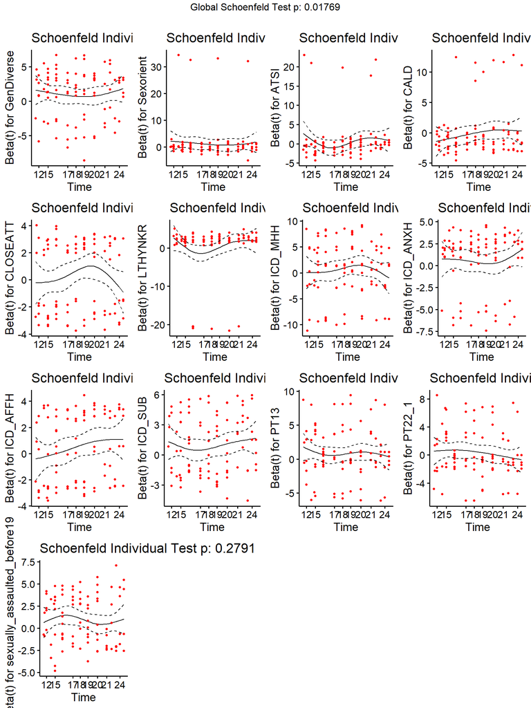

| variables | HR (95% CI) | p-value | exp(coef) | lower .95 | upper .95 |
| --- | --- | --- | --- | --- | --- |
| GenDiverseFemale | 2.42(1.34, 4.36) | 0.004 | 2.4211598 | 1.3447796 | 4.359089 |
| GenDiverseGender diverse | 0.76(0.08, 7.06) | 0.808 | 0.7580398 | 0.0814024 | 7.059058 |
| SexorientGay/Lesbian/Bisexual | 3.05(0.81,11.51) | 0.104 | 3.0520103 | 0.8094024 | 11.508202 |
| ATSIAboriginal or Torres Strait Islander | 2.05(0.60, 6.97) | 0.254 | 2.0490615 | 0.6026611 | 6.966857 |
| CALDYes | 1.24(0.49, 3.14) | 0.658 | 1.2355462 | 0.4865624 | 3.137469 |
| CLOSEATTYes | 0.91(0.47, 1.75) | 0.770 | 0.9059758 | 0.4682104 | 1.753041 |
| LTHYNKRHas a long-term health condition | 2.60(1.10, 6.15) | 0.033 | 2.5997555 | 1.0988658 | 6.150640 |
| ICD_MHHHas a lifetime mental disorder | 2.19(0.79, 6.06) | 0.136 | 2.1881861 | 0.7902600 | 6.058965 |
| ICD_ANXHHas a lifetime Anxiety Disorder | 2.15(1.13, 4.08) | 0.022 | 2.1457529 | 1.1294570 | 4.076521 |
| ICD_AFFHHas a lifetime Affective Disorder | 1.64(0.89, 3.01) | 0.117 | 1.6380786 | 0.8907586 | 3.012378 |
| ICD_SUBHas a lifetime Substance Use Disorder | 2.81(1.41, 5.60) | 0.004 | 2.8088473 | 1.4086691 | 5.600764 |
| PT13Yes | 2.71(1.27, 5.78) | 0.012 | 2.7120386 | 1.2729769 | 5.777916 |
| PT22_1Yes | 1.33(0.70, 2.50) | 0.385 | 1.3267708 | 0.7033540 | 2.502752 |
| sexually_assaulted_before19Yes | 3.80(2.22, 6.53) | <0.001 | 3.8042983 | 2.2164952 | 6.529536 |

[1] “Age first attempted to take own life (all attempts)” [1] “16 to 25”

|  | chisq | df | p |
| --- | --- | --- | --- |
| GenDiverse | 5.5110447 | 2 | 0.0635758 |
| Sexorient | 1.0948515 | 1 | 0.2953988 |
| ATSI | 1.3625511 | 1 | 0.2430958 |
| CALD | 0.3122932 | 1 | 0.5762764 |
| CLOSEATT | 0.7114718 | 1 | 0.3989556 |
| LTHYNKR | 0.5321477 | 1 | 0.4657053 |
| ICD_MHH | 1.2103633 | 1 | 0.2712602 |
| ICD_ANXH | 0.2001630 | 1 | 0.6545893 |
| ICD_AFFH | 1.5088045 | 1 | 0.2193216 |
| ICD_SUB | 12.1558962 | 1 | 0.0004893 |
| PT13 | 0.1617806 | 1 | 0.6875224 |
| PT22_1 | 0.5102552 | 1 | 0.4750284 |
| sexually_assaulted_before19 | 0.4120616 | 1 | 0.5209250 |
| GLOBAL | 29.4052650 | 14 | 0.0092067 |

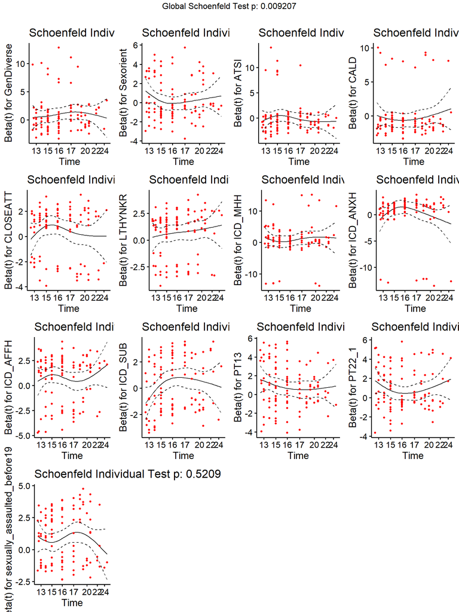

| variables | HR (95% CI) | p-value | exp(coef) | lower .95 | upper .95 |
| --- | --- | --- | --- | --- | --- |
| GenDiverseFemale | 0.76(0.44,1.32) | 0.330 | 0.7587891 | 0.4367293 | 1.318347 |
| GenDiverseGender diverse | 1.64(0.64,4.20) | 0.306 | 1.6392703 | 0.6401423 | 4.197828 |
| SexorientGay/Lesbian/Bisexual | 1.70(0.94,3.08) | 0.083 | 1.6991096 | 0.9388028 | 3.075165 |
| ATSIAboriginal or Torres Strait Islander | 1.05(0.40,2.74) | 0.918 | 1.0519824 | 0.4040151 | 2.739172 |
| CALDYes | 0.93(0.44,1.94) | 0.846 | 0.9295076 | 0.4449928 | 1.941570 |
| CLOSEATTYes | 1.77(1.07,2.93) | 0.029 | 1.7711570 | 1.0702364 | 2.931125 |
| LTHYNKRHas a long-term health condition | 1.85(1.06,3.23) | 0.034 | 1.8468893 | 1.0561952 | 3.229517 |
| ICD_MHHHas a lifetime mental disorder | 2.73(0.86,8.70) | 0.092 | 2.7337465 | 0.8591543 | 8.698518 |
| ICD_ANXHHas a lifetime Anxiety Disorder | 1.51(0.66,3.46) | 0.331 | 1.5115471 | 0.6599324 | 3.462135 |
| ICD_AFFHHas a lifetime Affective Disorder | 1.86(0.97,3.56) | 0.064 | 1.8619635 | 0.9726160 | 3.564519 |
| ICD_SUBHas a lifetime Substance Use Disorder | 0.92(0.58,1.46) | 0.712 | 0.9162971 | 0.5769549 | 1.455227 |
| PT13Yes | 3.45(1.79,6.63) | <0.001 | 3.4496826 | 1.7946636 | 6.630942 |
| PT22_1Yes | 2.50(1.32,4.74) | 0.006 | 2.5031556 | 1.3214862 | 4.741471 |
| sexually_assaulted_before19Yes | 1.81(1.06,3.10) | 0.033 | 1.8094466 | 1.0572892 | 3.096690 |

[1] “Age first attempted to take own life (all attempts)” [1] “26 to 41”

|  | chisq | df | p |
| --- | --- | --- | --- |
| GenDiverse | 6.3803817 | 2 | 0.0411640 |
| Sexorient | 0.0657400 | 1 | 0.7976435 |
| ATSI | 0.4279671 | 1 | 0.5129882 |
| CALD | 0.7563087 | 1 | 0.3844862 |
| CLOSEATT | 0.0053623 | 1 | 0.9416250 |
| LTHYNKR | 0.4356724 | 1 | 0.5092187 |
| ICD_MHH | 1.3929448 | 1 | 0.2379084 |
| ICD_ANXH | 0.2105474 | 1 | 0.6463387 |
| ICD_AFFH | 0.9030543 | 1 | 0.3419641 |
| ICD_SUB | 0.1907114 | 1 | 0.6623252 |
| PT13 | 0.0867688 | 1 | 0.7683259 |
| PT22_1 | 0.0017466 | 1 | 0.9666642 |
| sexually_assaulted_before19 | 16.0063242 | 1 | 0.0000631 |
| GLOBAL | 32.2100812 | 14 | 0.0037395 |

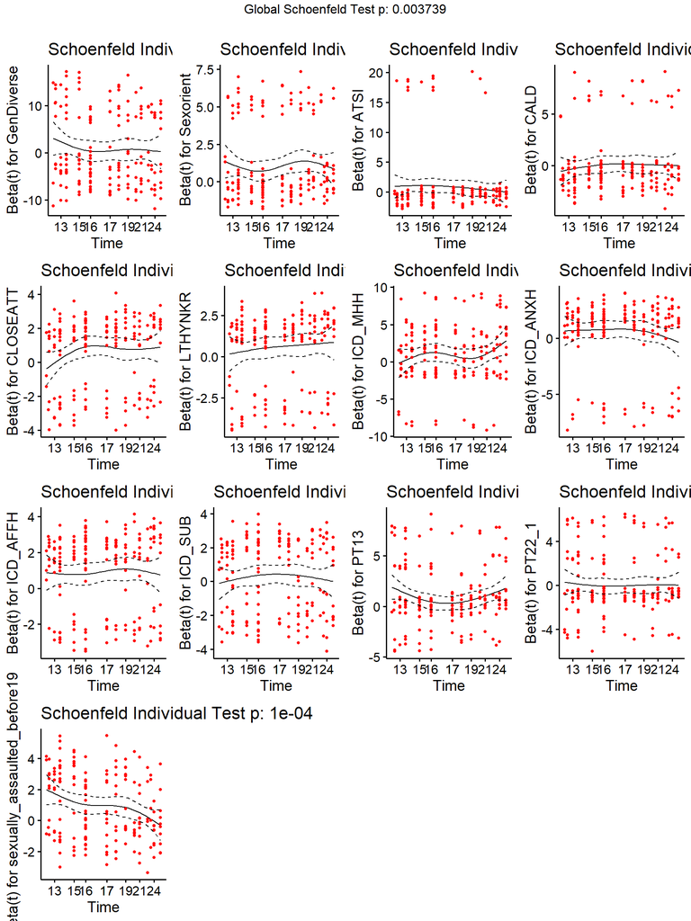

| variables | HR (95% CI) | p-value | exp(coef) | lower .95 | upper .95 |
| --- | --- | --- | --- | --- | --- |
| GenDiverseFemale | 0.75(0.49,1.14) | 0.182 | 0.7507335 | 0.4937592 | 1.141449 |
| GenDiverseGender diverse | 0.79(0.30,2.11) | 0.644 | 0.7932673 | 0.2977952 | 2.113107 |
| SexorientGay/Lesbian/Bisexual | 2.52(1.56,4.07) | <0.001 | 2.5173391 | 1.5580518 | 4.067257 |
| ATSIAboriginal or Torres Strait Islander | 1.35(0.76,2.40) | 0.307 | 1.3496598 | 0.7604155 | 2.395508 |
| CALDYes | 0.94(0.55,1.59) | 0.806 | 0.9353808 | 0.5497394 | 1.591549 |
| CLOSEATTYes | 1.75(1.14,2.68) | 0.012 | 1.7455561 | 1.1365467 | 2.680898 |
| LTHYNKRHas a long-term health condition | 1.98(1.26,3.12) | 0.003 | 1.9824046 | 1.2615552 | 3.115146 |
| ICD_MHHHas a lifetime mental disorder | 1.68(0.68,4.12) | 0.259 | 1.6790195 | 0.6848902 | 4.116143 |
| ICD_ANXHHas a lifetime Anxiety Disorder | 1.83(1.06,3.17) | 0.033 | 1.8284285 | 1.0551103 | 3.168532 |
| ICD_AFFHHas a lifetime Affective Disorder | 2.36(1.54,3.62) | <0.001 | 2.3639325 | 1.5444999 | 3.618114 |
| ICD_SUBHas a lifetime Substance Use Disorder | 1.58(1.04,2.39) | 0.032 | 1.5806234 | 1.0438206 | 2.393486 |
| PT13Yes | 2.89(1.74,4.79) | <0.001 | 2.8863782 | 1.7381401 | 4.793158 |
| PT22_1Yes | 0.90(0.56,1.45) | 0.657 | 0.8975285 | 0.5569992 | 1.446245 |
| sexually_assaulted_before19Yes | 2.36(1.50,3.71) | <0.001 | 2.3618134 | 1.5022615 | 3.713177 |

[1] “Age first attempted to take own life (all attempts)” [1] “42 to 57”

|  | chisq | df | p |
| --- | --- | --- | --- |
| GenDiverse | 3.6261273 | 2 | 0.1631535 |
| Sexorient | 1.1528974 | 1 | 0.2829434 |
| ATSI | 0.1660276 | 1 | 0.6836666 |
| CALD | 0.0143020 | 1 | 0.9048073 |
| CLOSEATT | 0.1331702 | 1 | 0.7151675 |
| LTHYNKR | 0.0051446 | 1 | 0.9428202 |
| ICD_MHH | 0.2227635 | 1 | 0.6369423 |
| ICD_ANXH | 0.8717606 | 1 | 0.3504684 |
| ICD_AFFH | 2.3611197 | 1 | 0.1243929 |
| ICD_SUB | 0.1693767 | 1 | 0.6806663 |
| PT13 | 0.8626962 | 1 | 0.3529853 |
| PT22_1 | 0.2745249 | 1 | 0.6003125 |
| sexually_assaulted_before19 | 1.9245064 | 1 | 0.1653607 |
| GLOBAL | 13.8977586 | 14 | 0.4573557 |

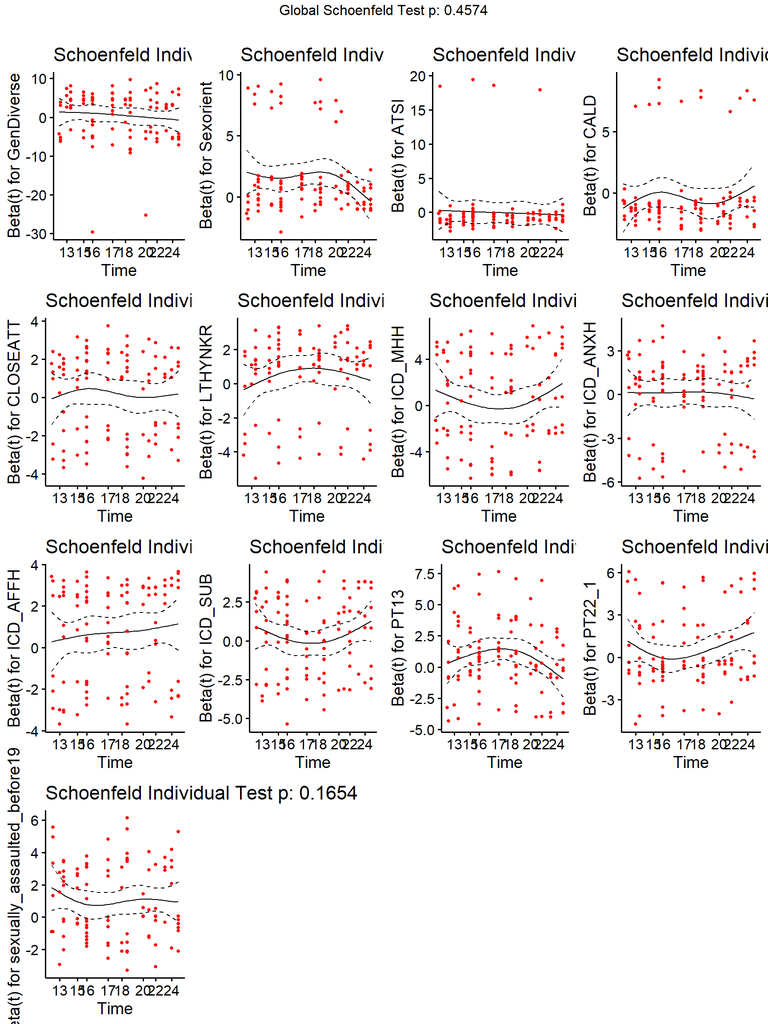

| variables | HR (95% CI) | p-value | exp(coef) | lower .95 | upper .95 |
| --- | --- | --- | --- | --- | --- |
| GenDiverseFemale | 1.41(0.78,2.54) | 0.260 | 1.4072085 | 0.7795680 | 2.540171 |
| GenDiverseGender diverse | 0.45(0.09,2.42) | 0.358 | 0.4541181 | 0.0852076 | 2.420244 |
| SexorientGay/Lesbian/Bisexual | 4.74(2.28,9.87) | <0.001 | 4.7440641 | 2.2811538 | 9.866123 |
| ATSIAboriginal or Torres Strait Islander | 1.20(0.44,3.22) | 0.725 | 1.1952333 | 0.4433378 | 3.222335 |
| CALDYes | 0.71(0.35,1.42) | 0.335 | 0.7073952 | 0.3511708 | 1.424970 |
| CLOSEATTYes | 1.11(0.62,1.98) | 0.719 | 1.1120369 | 0.6248517 | 1.979071 |
| LTHYNKRHas a long-term health condition | 1.11(0.57,2.15) | 0.759 | 1.1094478 | 0.5732894 | 2.147039 |
| ICD_MHHHas a lifetime mental disorder | 2.57(0.95,6.98) | 0.068 | 2.5688084 | 0.9450966 | 6.982119 |
| ICD_ANXHHas a lifetime Anxiety Disorder | 0.95(0.49,1.84) | 0.878 | 0.9490664 | 0.4883632 | 1.844380 |
| ICD_AFFHHas a lifetime Affective Disorder | 1.68(0.95,2.97) | 0.078 | 1.6799181 | 0.9509089 | 2.967818 |
| ICD_SUBHas a lifetime Substance Use Disorder | 1.02(0.53,1.98) | 0.955 | 1.0191303 | 0.5254026 | 1.976820 |
| PT13Yes | 3.32(1.78,6.21) | <0.001 | 3.3201296 | 1.7757679 | 6.207602 |
| PT22_1Yes | 1.65(0.94,2.89) | 0.086 | 1.6456375 | 0.9386710 | 2.885061 |
| sexually_assaulted_before19Yes | 2.99(1.62,5.51) | 0.001 | 2.9858559 | 1.6176397 | 5.511323 |

[1] “Age first time made a plan for taking own life” [1] “>57”

|  | chisq | df | p |
| --- | --- | --- | --- |
| GenDiverse | 2.8678082 | 2 | 0.2383765 |
| Sexorient | 0.0307453 | 1 | 0.8608099 |
| ATSI | 4.0978396 | 1 | 0.0429380 |
| CALD | 4.1780865 | 1 | 0.0409499 |
| CLOSEATT | 1.7827517 | 1 | 0.1818118 |
| LTHYNKR | 1.2455115 | 1 | 0.2644115 |
| ICD_MHH | 1.2744564 | 1 | 0.2589323 |
| ICD_ANXH | 0.1345838 | 1 | 0.7137260 |
| ICD_AFFH | 0.1840548 | 1 | 0.6679115 |
| ICD_SUB | 1.4136656 | 1 | 0.2344488 |
| PT13 | 7.2973956 | 1 | 0.0069055 |
| PT22_1 | 7.3078034 | 1 | 0.0068656 |
| sexually_assaulted_before19 | 2.1751067 | 1 | 0.1402598 |
| GLOBAL | 35.4821906 | 14 | 0.0012467 |

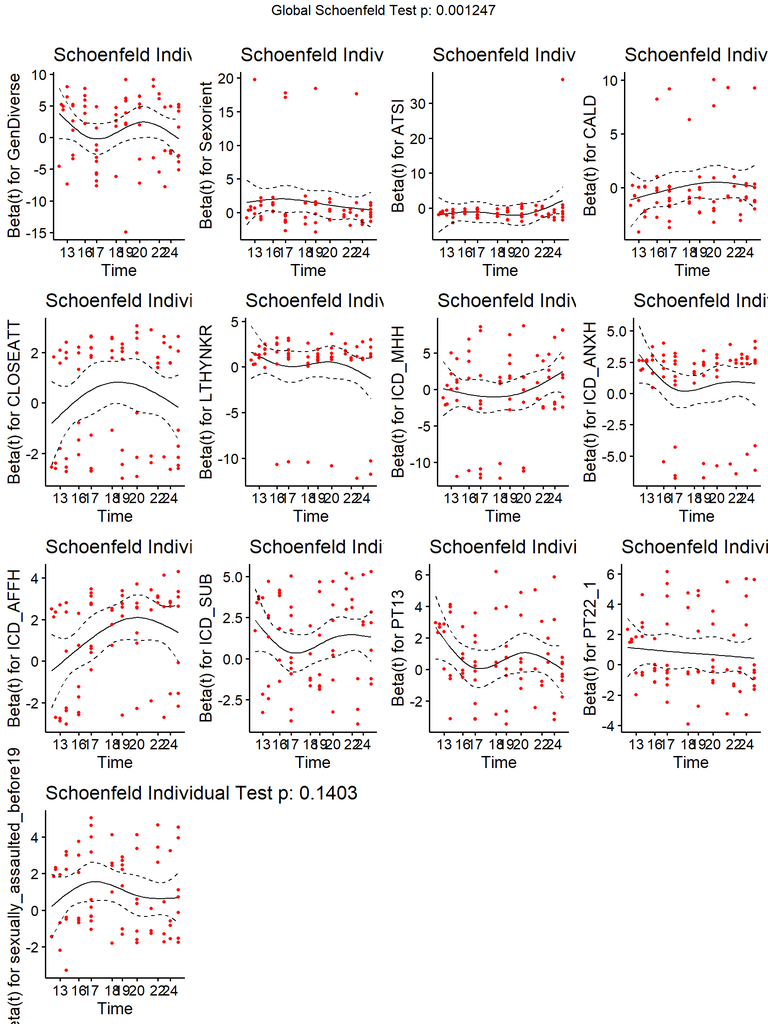

| variables | HR (95% CI) | p-value | exp(coef) | lower .95 | upper .95 |
| --- | --- | --- | --- | --- | --- |
| GenDiverseFemale | 1.57(0.84, 2.97) | 0.165 | 1.5749361 | 0.8364093 | 2.965562 |
| GenDiverseGender diverse | 0.80(0.09, 6.78) | 0.835 | 0.7951282 | 0.0932003 | 6.783552 |
| SexorientGay/Lesbian/Bisexual | 3.54(0.87,14.36) | 0.083 | 3.5396746 | 0.8723489 | 14.362713 |
| ATSIAboriginal or Torres Strait Islander | 0.77(0.09, 6.40) | 0.813 | 0.7741326 | 0.0936649 | 6.398142 |
| CALDYes | 1.40(0.49, 3.97) | 0.531 | 1.3986783 | 0.4928036 | 3.969738 |
| CLOSEATTYes | 1.18(0.58, 2.39) | 0.656 | 1.1755066 | 0.5787481 | 2.387595 |
| LTHYNKRHas a long-term health condition | 1.33(0.54, 3.30) | 0.538 | 1.3322766 | 0.5372671 | 3.303684 |
| ICD_MHHHas a lifetime mental disorder | 1.33(0.38, 4.58) | 0.657 | 1.3261541 | 0.3840998 | 4.578718 |
| ICD_ANXHHas a lifetime Anxiety Disorder | 3.53(1.64, 7.63) | 0.002 | 3.5335523 | 1.6356304 | 7.633749 |
| ICD_AFFHHas a lifetime Affective Disorder | 2.82(1.42, 5.60) | 0.005 | 2.8217788 | 1.4208146 | 5.604134 |
| ICD_SUBHas a lifetime Substance Use Disorder | 4.04(1.96, 8.32) | <0.001 | 4.0363982 | 1.9590476 | 8.316546 |
| PT13Yes | 2.56(1.38, 4.73) | 0.004 | 2.5564193 | 1.3822614 | 4.727962 |
| PT22_1Yes | 1.70(0.97, 2.99) | 0.070 | 1.7023398 | 0.9687788 | 2.991354 |
| sexually_assaulted_before19Yes | 3.40(1.93, 6.01) | <0.001 | 3.4025562 | 1.9258478 | 6.011580 |

[1] “Age first time made a plan for taking own life” [1] “16 to 25”

|  | chisq | df | p |
| --- | --- | --- | --- |
| GenDiverse | 3.5901434 | 2 | 0.1661155 |
| Sexorient | 0.2800911 | 1 | 0.5966415 |
| ATSI | 3.0981390 | 1 | 0.0783818 |
| CALD | 0.0044772 | 1 | 0.9466517 |
| CLOSEATT | 0.0772100 | 1 | 0.7811145 |
| LTHYNKR | 0.8721176 | 1 | 0.3503697 |
| ICD_MHH | 0.0001189 | 1 | 0.9913005 |
| ICD_ANXH | 0.0010573 | 1 | 0.9740603 |
| ICD_AFFH | 0.3841354 | 1 | 0.5353983 |
| ICD_SUB | 1.9205810 | 1 | 0.1657926 |
| PT13 | 0.7024333 | 1 | 0.4019673 |
| PT22_1 | 6.6228487 | 1 | 0.0100679 |
| sexually_assaulted_before19 | 0.5892837 | 1 | 0.4426962 |
| GLOBAL | 19.0355322 | 14 | 0.1635960 |

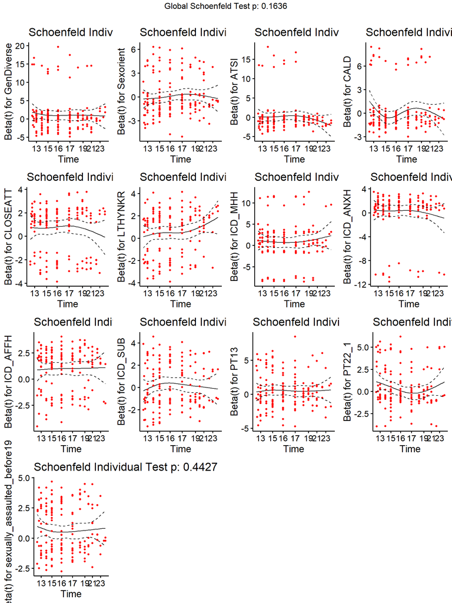

| variables | HR (95% CI) | p-value | exp(coef) | lower .95 | upper .95 |
| --- | --- | --- | --- | --- | --- |
| GenDiverseFemale | 0.89(0.57,1.38) | 0.602 | 0.8886693 | 0.5710257 | 1.383008 |
| GenDiverseGender diverse | 1.70(0.77,3.79) | 0.194 | 1.7023254 | 0.7650382 | 3.787931 |
| SexorientGay/Lesbian/Bisexual | 1.15(0.69,1.90) | 0.596 | 1.1463279 | 0.6929763 | 1.896266 |
| ATSIAboriginal or Torres Strait Islander | 0.91(0.40,2.07) | 0.826 | 0.9120977 | 0.4016618 | 2.071201 |
| CALDYes | 1.03(0.60,1.76) | 0.928 | 1.0253707 | 0.5966814 | 1.762055 |
| CLOSEATTYes | 1.98(1.29,3.03) | 0.002 | 1.9776649 | 1.2906902 | 3.030285 |
| LTHYNKRHas a long-term health condition | 1.72(1.13,2.63) | 0.013 | 1.7219291 | 1.1261186 | 2.632973 |
| ICD_MHHHas a lifetime mental disorder | 2.92(1.25,6.84) | 0.015 | 2.9223783 | 1.2483464 | 6.841286 |
| ICD_ANXHHas a lifetime Anxiety Disorder | 1.45(0.78,2.72) | 0.243 | 1.4536220 | 0.7781095 | 2.715578 |
| ICD_AFFHHas a lifetime Affective Disorder | 2.34(1.43,3.82) | 0.001 | 2.3377171 | 1.4307324 | 3.819667 |
| ICD_SUBHas a lifetime Substance Use Disorder | 0.94(0.61,1.46) | 0.795 | 0.9436514 | 0.6100938 | 1.459576 |
| PT13Yes | 2.13(1.21,3.75) | 0.010 | 2.1270257 | 1.2071508 | 3.747865 |
| PT22_1Yes | 1.38(0.84,2.25) | 0.202 | 1.3773332 | 0.8442749 | 2.246954 |
| sexually_assaulted_before19Yes | 1.74(1.10,2.74) | 0.018 | 1.7373416 | 1.1034640 | 2.735346 |

[1] “Age first time made a plan for taking own life” [1] “26 to 41”

|  | chisq | df | p |
| --- | --- | --- | --- |
| GenDiverse | 4.3382939 | 2 | 0.1142751 |
| Sexorient | 5.8964307 | 1 | 0.0151716 |
| ATSI | 2.9901514 | 1 | 0.0837723 |
| CALD | 0.0997076 | 1 | 0.7521809 |
| CLOSEATT | 0.3162863 | 1 | 0.5738481 |
| LTHYNKR | 0.0207820 | 1 | 0.8853744 |
| ICD_MHH | 0.0002710 | 1 | 0.9868667 |
| ICD_ANXH | 0.3500250 | 1 | 0.5540990 |
| ICD_AFFH | 0.9447562 | 1 | 0.3310577 |
| ICD_SUB | 0.2138271 | 1 | 0.6437842 |
| PT13 | 0.9155544 | 1 | 0.3386450 |
| PT22_1 | 0.2047277 | 1 | 0.6509315 |
| sexually_assaulted_before19 | 13.7522132 | 1 | 0.0002086 |
| GLOBAL | 28.3570753 | 14 | 0.0127522 |

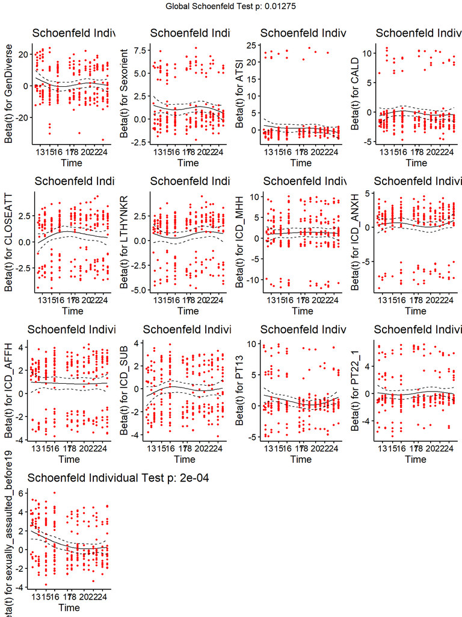

| variables | HR (95% CI) | p-value | exp(coef) | lower .95 | upper .95 |
| --- | --- | --- | --- | --- | --- |
| GenDiverseFemale | 0.82(0.58,1.16) | 0.269 | 0.8235522 | 0.5840048 | 1.161357 |
| GenDiverseGender diverse | 0.68(0.24,1.95) | 0.474 | 0.6803950 | 0.2377467 | 1.947188 |
| SexorientGay/Lesbian/Bisexual | 2.65(1.67,4.21) | <0.001 | 2.6523344 | 1.6728780 | 4.205254 |
| ATSIAboriginal or Torres Strait Islander | 1.26(0.69,2.30) | 0.458 | 1.2569168 | 0.6879109 | 2.296576 |
| CALDYes | 0.67(0.43,1.04) | 0.078 | 0.6670267 | 0.4261977 | 1.043940 |
| CLOSEATTYes | 1.96(1.33,2.87) | 0.001 | 1.9575851 | 1.3346893 | 2.871185 |
| LTHYNKRHas a long-term health condition | 1.92(1.31,2.81) | 0.001 | 1.9222514 | 1.3146364 | 2.810701 |
| ICD_MHHHas a lifetime mental disorder | 2.55(1.25,5.20) | 0.010 | 2.5522292 | 1.2526310 | 5.200154 |
| ICD_ANXHHas a lifetime Anxiety Disorder | 1.98(1.27,3.09) | 0.003 | 1.9790498 | 1.2686627 | 3.087218 |
| ICD_AFFHHas a lifetime Affective Disorder | 2.64(1.86,3.74) | <0.001 | 2.6384118 | 1.8622569 | 3.738054 |
| ICD_SUBHas a lifetime Substance Use Disorder | 1.09(0.77,1.55) | 0.623 | 1.0913789 | 0.7700969 | 1.546699 |
| PT13Yes | 2.23(1.45,3.43) | <0.001 | 2.2339450 | 1.4534645 | 3.433528 |
| PT22_1Yes | 0.94(0.63,1.41) | 0.780 | 0.9447241 | 0.6338655 | 1.408033 |
| sexually_assaulted_before19Yes | 1.71(1.18,2.48) | 0.005 | 1.7103010 | 1.1793566 | 2.480275 |

[1] “Age first time made a plan for taking own life” [1] “42 to 57”

|  | chisq | df | p |
| --- | --- | --- | --- |
| GenDiverse | 0.1417497 | 2 | 0.9315785 |
| Sexorient | 0.3111868 | 1 | 0.5769529 |
| ATSI | 0.7828320 | 1 | 0.3762764 |
| CALD | 0.7336949 | 1 | 0.3916882 |
| CLOSEATT | 0.0009250 | 1 | 0.9757373 |
| LTHYNKR | 3.8954707 | 1 | 0.0484165 |
| ICD_MHH | 1.0777364 | 1 | 0.2992045 |
| ICD_ANXH | 3.4730664 | 1 | 0.0623756 |
| ICD_AFFH | 1.0158721 | 1 | 0.3135002 |
| ICD_SUB | 0.0009147 | 1 | 0.9758718 |
| PT13 | 11.8641141 | 1 | 0.0005723 |
| PT22_1 | 0.3266568 | 1 | 0.5676344 |
| sexually_assaulted_before19 | 0.4332584 | 1 | 0.5103944 |
| GLOBAL | 27.1477894 | 14 | 0.0184191 |

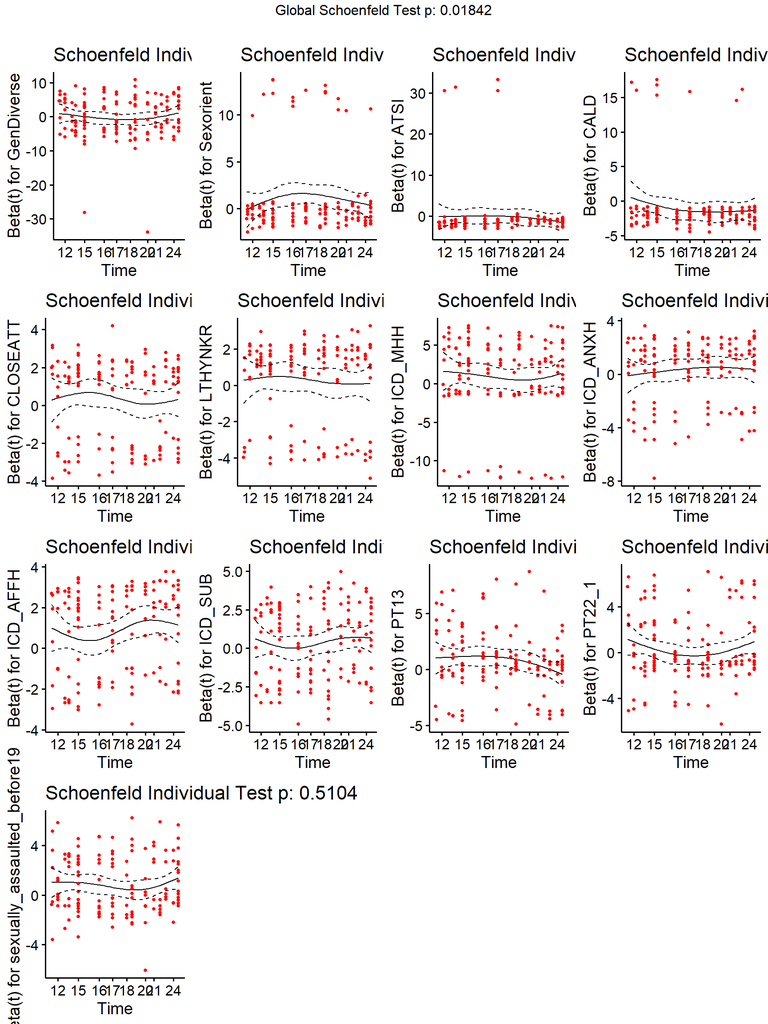

| variables | HR (95% CI) | p-value | exp(coef) | lower .95 | upper .95 |
| --- | --- | --- | --- | --- | --- |
| GenDiverseFemale | 0.72(0.45, 1.17) | 0.189 | 0.7224470 | 0.4460292 | 1.1701693 |
| GenDiverseGender diverse | 0.28(0.06, 1.36) | 0.117 | 0.2803749 | 0.0578878 | 1.3579732 |
| SexorientGay/Lesbian/Bisexual | 1.63(0.72, 3.72) | 0.246 | 1.6321706 | 0.7165090 | 3.7180009 |
| ATSIAboriginal or Torres Strait Islander | 0.63(0.24, 1.68) | 0.359 | 0.6317008 | 0.2376847 | 1.6788880 |
| CALDYes | 0.34(0.15, 0.76) | 0.010 | 0.3361760 | 0.1485113 | 0.7609815 |
| CLOSEATTYes | 1.52(0.89, 2.59) | 0.126 | 1.5208178 | 0.8917842 | 2.5935496 |
| LTHYNKRHas a long-term health condition | 1.29(0.72, 2.32) | 0.389 | 1.2939486 | 0.7214856 | 2.3206324 |
| ICD_MHHHas a lifetime mental disorder | 4.99(1.74,14.35) | 0.003 | 4.9926876 | 1.7366026 | 14.3538475 |
| ICD_ANXHHas a lifetime Anxiety Disorder | 1.21(0.66, 2.20) | 0.537 | 1.2080629 | 0.6636701 | 2.1990082 |
| ICD_AFFHHas a lifetime Affective Disorder | 2.15(1.30, 3.58) | 0.004 | 2.1546538 | 1.2965454 | 3.5806946 |
| ICD_SUBHas a lifetime Substance Use Disorder | 1.25(0.72, 2.15) | 0.432 | 1.2458318 | 0.7208780 | 2.1530644 |
| PT13Yes | 2.99(1.50, 5.96) | 0.002 | 2.9881632 | 1.4992372 | 5.9557750 |
| PT22_1Yes | 1.08(0.57, 2.03) | 0.812 | 1.0799646 | 0.5743936 | 2.0305302 |
| sexually_assaulted_before19Yes | 2.32(1.39, 3.87) | 0.002 | 2.3192864 | 1.3890823 | 3.8724049 |

[1] “Age first time seriously thought about taking own life” [1] “>57”

|  | chisq | df | p |
| --- | --- | --- | --- |
| GenDiverse | 3.3915023 | 2 | 0.1834614 |
| Sexorient | 1.9313808 | 1 | 0.1646075 |
| ATSI | 4.5477662 | 1 | 0.0329617 |
| CALD | 1.4436259 | 1 | 0.2295535 |
| CLOSEATT | 5.1568316 | 1 | 0.0231551 |
| LTHYNKR | 1.2237442 | 1 | 0.2686271 |
| ICD_MHH | 0.3789944 | 1 | 0.5381419 |
| ICD_ANXH | 0.2180653 | 1 | 0.6405180 |
| ICD_AFFH | 0.9646883 | 1 | 0.3260085 |
| ICD_SUB | 2.6348179 | 1 | 0.1045440 |
| PT13 | 9.9004580 | 1 | 0.0016524 |
| PT22_1 | 5.5737850 | 1 | 0.0182313 |
| sexually_assaulted_before19 | 13.4487403 | 1 | 0.0002452 |
| GLOBAL | 53.4867268 | 14 | 0.0000016 |

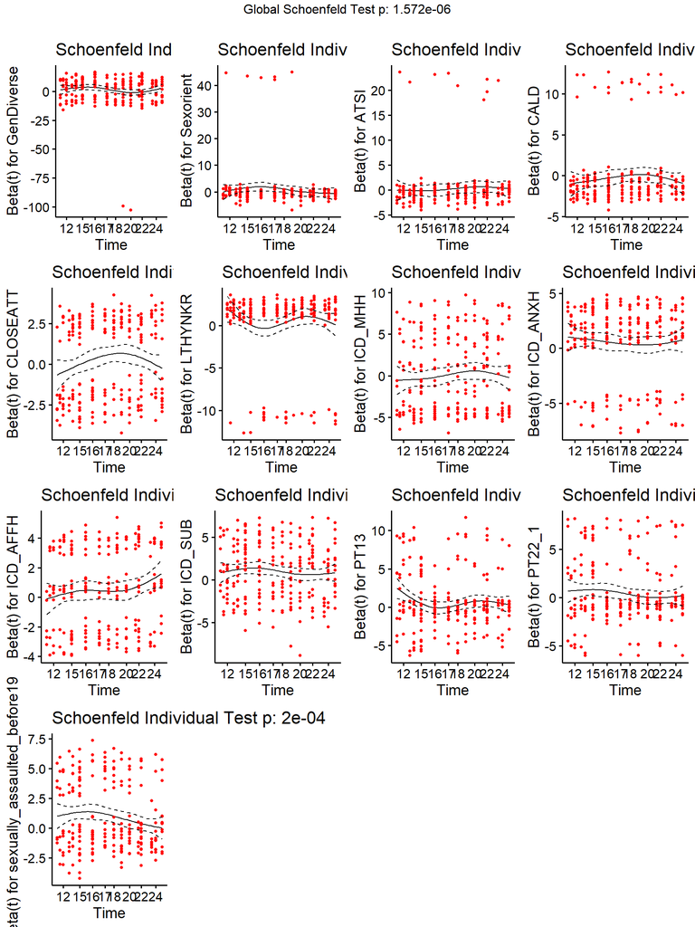

| variables | HR (95% CI) | p-value | exp(coef) | lower .95 | upper .95 |
| --- | --- | --- | --- | --- | --- |
| GenDiverseFemale | 1.25(0.79,1.98) | 0.349 | 1.2466477 | 0.7864509 | 1.976132 |
| GenDiverseGender diverse | 0.58(0.09,3.86) | 0.580 | 0.5849780 | 0.0885515 | 3.864408 |
| SexorientGay/Lesbian/Bisexual | 1.85(0.68,5.02) | 0.228 | 1.8503076 | 0.6817238 | 5.022031 |
| ATSIAboriginal or Torres Strait Islander | 1.88(0.88,4.01) | 0.103 | 1.8827592 | 0.8831346 | 4.013864 |
| CALDYes | 0.92(0.51,1.64) | 0.770 | 0.9167421 | 0.5124904 | 1.639867 |
| CLOSEATTYes | 1.38(0.93,2.06) | 0.116 | 1.3812799 | 0.9252099 | 2.062163 |
| LTHYNKRHas a long-term health condition | 1.70(1.02,2.86) | 0.045 | 1.7040177 | 1.0162486 | 2.857250 |
| ICD_MHHHas a lifetime mental disorder | 0.88(0.48,1.62) | 0.690 | 0.8838560 | 0.4818651 | 1.621204 |
| ICD_ANXHHas a lifetime Anxiety Disorder | 2.43(1.58,3.74) | <0.001 | 2.4282296 | 1.5783109 | 3.735829 |
| ICD_AFFHHas a lifetime Affective Disorder | 1.91(1.24,2.92) | 0.003 | 1.9054395 | 1.2422683 | 2.922637 |
| ICD_SUBHas a lifetime Substance Use Disorder | 2.37(1.31,4.28) | 0.005 | 2.3705864 | 1.3134900 | 4.278434 |
| PT13Yes | 1.99(1.29,3.09) | 0.002 | 1.9927129 | 1.2860024 | 3.087790 |
| PT22_1Yes | 1.45(0.98,2.17) | 0.067 | 1.4540351 | 0.9758587 | 2.166520 |
| sexually_assaulted_before19Yes | 2.23(1.54,3.22) | <0.001 | 2.2286745 | 1.5422417 | 3.220630 |

[1] “Age first time seriously thought about taking own life” [1] “16 to 25”

|  | chisq | df | p |
| --- | --- | --- | --- |
| GenDiverse | 2.4420441 | 2 | 0.2949286 |
| Sexorient | 0.0006879 | 1 | 0.9790752 |
| ATSI | 1.1368778 | 1 | 0.2863130 |
| CALD | 0.1950912 | 1 | 0.6587126 |
| CLOSEATT | 0.0806332 | 1 | 0.7764411 |
| LTHYNKR | 5.1233114 | 1 | 0.0236065 |
| ICD_MHH | 0.0436704 | 1 | 0.8344680 |
| ICD_ANXH | 1.1134282 | 1 | 0.2913379 |
| ICD_AFFH | 0.7057941 | 1 | 0.4008436 |
| ICD_SUB | 4.3883819 | 1 | 0.0361846 |
| PT13 | 1.1646790 | 1 | 0.2804973 |
| PT22_1 | 0.0100874 | 1 | 0.9199982 |
| sexually_assaulted_before19 | 0.8218408 | 1 | 0.3646425 |
| GLOBAL | 20.0688741 | 14 | 0.1279849 |

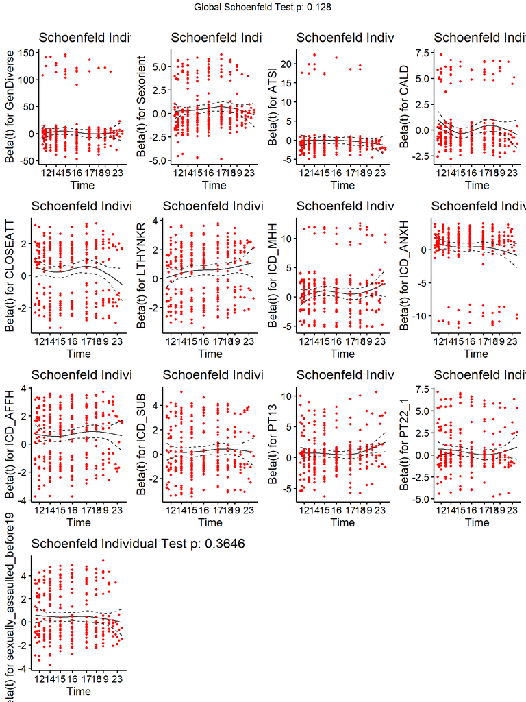

| variables | HR (95% CI) | p-value | exp(coef) | lower .95 | upper .95 |
| --- | --- | --- | --- | --- | --- |
| GenDiverseFemale | 0.96(0.73,1.26) | 0.765 | 0.9593385 | 0.7304819 | 1.259895 |
| GenDiverseGender diverse | 1.16(0.64,2.11) | 0.620 | 1.1626382 | 0.6408055 | 2.109419 |
| SexorientGay/Lesbian/Bisexual | 1.71(1.26,2.31) | 0.001 | 1.7071645 | 1.2601871 | 2.312681 |
| ATSIAboriginal or Torres Strait Islander | 0.81(0.43,1.52) | 0.511 | 0.8088773 | 0.4298031 | 1.522284 |
| CALDYes | 1.23(0.84,1.79) | 0.280 | 1.2308669 | 0.8446035 | 1.793780 |
| CLOSEATTYes | 1.41(1.09,1.82) | 0.009 | 1.4099099 | 1.0917859 | 1.820729 |
| LTHYNKRHas a long-term health condition | 1.59(1.21,2.09) | 0.001 | 1.5874308 | 1.2055715 | 2.090242 |
| ICD_MHHHas a lifetime mental disorder | 2.07(1.23,3.49) | 0.006 | 2.0711270 | 1.2301242 | 3.487101 |
| ICD_ANXHHas a lifetime Anxiety Disorder | 1.74(1.15,2.65) | 0.010 | 1.7420579 | 1.1466024 | 2.646746 |
| ICD_AFFHHas a lifetime Affective Disorder | 1.78(1.35,2.36) | <0.001 | 1.7827451 | 1.3457525 | 2.361638 |
| ICD_SUBHas a lifetime Substance Use Disorder | 1.12(0.83,1.51) | 0.457 | 1.1193738 | 0.8316955 | 1.506558 |
| PT13Yes | 2.54(1.71,3.77) | <0.001 | 2.5356960 | 1.7052209 | 3.770628 |
| PT22_1Yes | 1.37(0.97,1.96) | 0.078 | 1.3740834 | 0.9655988 | 1.955372 |
| sexually_assaulted_before19Yes | 1.35(1.01,1.80) | 0.044 | 1.3461201 | 1.0087776 | 1.796272 |

[1] “Age first time seriously thought about taking own life” [1] “26 to 41”

|  | chisq | df | p |
| --- | --- | --- | --- |
| GenDiverse | 4.9063308 | 2 | 0.0860209 |
| Sexorient | 4.3683152 | 1 | 0.0366132 |
| ATSI | 2.0793533 | 1 | 0.1493034 |
| CALD | 0.1288899 | 1 | 0.7195858 |
| CLOSEATT | 0.1710073 | 1 | 0.6792182 |
| LTHYNKR | 3.5293729 | 1 | 0.0602906 |
| ICD_MHH | 0.0006480 | 1 | 0.9796908 |
| ICD_ANXH | 0.8129165 | 1 | 0.3672594 |
| ICD_AFFH | 1.0220284 | 1 | 0.3120384 |
| ICD_SUB | 0.8971289 | 1 | 0.3435527 |
| PT13 | 2.5810667 | 1 | 0.1081488 |
| PT22_1 | 0.0736176 | 1 | 0.7861406 |
| sexually_assaulted_before19 | 20.9681725 | 1 | 0.0000047 |
| GLOBAL | 35.4953206 | 14 | 0.0012411 |

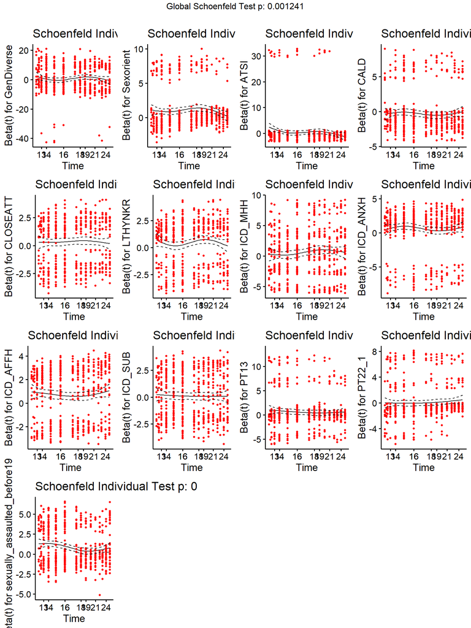

| variables | HR (95% CI) | p-value | exp(coef) | lower .95 | upper .95 |
| --- | --- | --- | --- | --- | --- |
| GenDiverseFemale | 0.84(0.67,1.06) | 0.145 | 0.8447754 | 0.6733993 | 1.0597657 |
| GenDiverseGender diverse | 0.62(0.32,1.22) | 0.168 | 0.6225375 | 0.3173705 | 1.2211372 |
| SexorientGay/Lesbian/Bisexual | 2.24(1.63,3.07) | <0.001 | 2.2399857 | 1.6340237 | 3.0706628 |
| ATSIAboriginal or Torres Strait Islander | 1.19(0.72,1.95) | 0.496 | 1.1874604 | 0.7242501 | 1.9469272 |
| CALDYes | 0.71(0.53,0.95) | 0.021 | 0.7094676 | 0.5304315 | 0.9489336 |
| CLOSEATTYes | 1.43(1.14,1.81) | 0.003 | 1.4329420 | 1.1358234 | 1.8077835 |
| LTHYNKRHas a long-term health condition | 1.59(1.27,2.01) | <0.001 | 1.5937399 | 1.2661611 | 2.0060693 |
| ICD_MHHHas a lifetime mental disorder | 1.31(0.86,2.01) | 0.212 | 1.3113496 | 0.8571291 | 2.0062761 |
| ICD_ANXHHas a lifetime Anxiety Disorder | 2.09(1.54,2.84) | <0.001 | 2.0889729 | 1.5351198 | 2.8426497 |
| ICD_AFFHHas a lifetime Affective Disorder | 2.22(1.77,2.79) | <0.001 | 2.2232216 | 1.7740565 | 2.7861087 |
| ICD_SUBHas a lifetime Substance Use Disorder | 1.35(1.07,1.70) | 0.012 | 1.3471215 | 1.0676983 | 1.6996715 |
| PT13Yes | 1.67(1.18,2.36) | 0.004 | 1.6703863 | 1.1824913 | 2.3595864 |
| PT22_1Yes | 1.09(0.82,1.45) | 0.556 | 1.0893968 | 0.8194115 | 1.4483388 |
| sexually_assaulted_before19Yes | 2.26(1.76,2.91) | <0.001 | 2.2644778 | 1.7620880 | 2.9101042 |

[1] “Age first time seriously thought about taking own life” [1] “42 to 57”

|  | chisq | df | p |
| --- | --- | --- | --- |
| GenDiverse | 0.0027935 | 2 | 0.9986042 |
| Sexorient | 2.1767175 | 1 | 0.1401130 |
| ATSI | 0.1371087 | 1 | 0.7111725 |
| CALD | 0.0531694 | 1 | 0.8176374 |
| CLOSEATT | 1.0532324 | 1 | 0.3047638 |
| LTHYNKR | 0.5684668 | 1 | 0.4508688 |
| ICD_MHH | 0.9909364 | 1 | 0.3195136 |
| ICD_ANXH | 0.0500742 | 1 | 0.8229342 |
| ICD_AFFH | 6.1567587 | 1 | 0.0130911 |
| ICD_SUB | 0.9647355 | 1 | 0.3259966 |
| PT13 | 14.4695372 | 1 | 0.0001424 |
| PT22_1 | 0.0031331 | 1 | 0.9553625 |
| sexually_assaulted_before19 | 0.0058199 | 1 | 0.9391897 |
| GLOBAL | 36.9632714 | 14 | 0.0007473 |

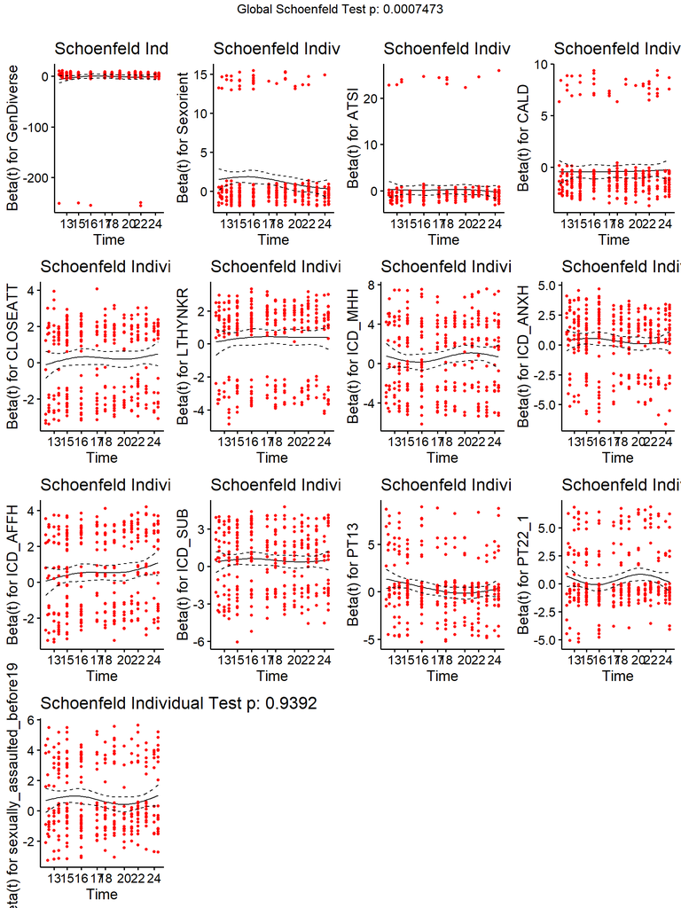

| variables | HR (95% CI) | p-value | exp(coef) | lower .95 | upper .95 |
| --- | --- | --- | --- | --- | --- |
| GenDiverseFemale | 1.00(0.72,1.40) | 0.993 | 1.0014673 | 0.7151764 | 1.402363 |
| GenDiverseGender diverse | 0.51(0.19,1.33) | 0.167 | 0.5067357 | 0.1937419 | 1.325377 |
| SexorientGay/Lesbian/Bisexual | 1.73(1.00,2.99) | 0.052 | 1.7286823 | 0.9981990 | 2.993734 |
| ATSIAboriginal or Torres Strait Islander | 1.28(0.68,2.39) | 0.445 | 1.2768404 | 0.6825185 | 2.388685 |
| CALDYes | 0.72(0.46,1.13) | 0.151 | 0.7210398 | 0.4616740 | 1.126116 |
| CLOSEATTYes | 1.39(1.01,1.92) | 0.046 | 1.3893500 | 1.0075948 | 1.915744 |
| LTHYNKRHas a long-term health condition | 1.47(1.02,2.12) | 0.042 | 1.4674933 | 1.0157226 | 2.120201 |
| ICD_MHHHas a lifetime mental disorder | 1.79(1.03,3.10) | 0.040 | 1.7870321 | 1.0295659 | 3.101777 |
| ICD_ANXHHas a lifetime Anxiety Disorder | 1.39(0.92,2.10) | 0.115 | 1.3920511 | 0.9239978 | 2.097198 |
| ICD_AFFHHas a lifetime Affective Disorder | 1.67(1.19,2.35) | 0.003 | 1.6730784 | 1.1917446 | 2.348818 |
| ICD_SUBHas a lifetime Substance Use Disorder | 1.82(1.24,2.67) | 0.002 | 1.8175648 | 1.2378492 | 2.668776 |
| PT13Yes | 1.65(1.03,2.64) | 0.037 | 1.6519468 | 1.0322781 | 2.643598 |
| PT22_1Yes | 1.26(0.86,1.85) | 0.230 | 1.2625882 | 0.8635357 | 1.846049 |
| sexually_assaulted_before19Yes | 2.05(1.42,2.94) | <0.001 | 2.0462781 | 1.4239301 | 2.940632 |

[1] “Age first time self-harmed” [1] “>57”

|  | chisq | df | p |
| --- | --- | --- | --- |
| GenDiverse | 1.8069785 | 2 | 0.4051535 |
| Sexorient | 0.9444613 | 1 | 0.3311331 |
| ATSI | 0.0000000 | 1 | 0.9999565 |
| CALD | 2.2379908 | 1 | 0.1346558 |
| CLOSEATT | 0.1784095 | 1 | 0.6727437 |
| LTHYNKR | 0.2272474 | 1 | 0.6335724 |
| ICD_MHH | 0.5589488 | 1 | 0.4546841 |
| ICD_ANXH | 1.3234152 | 1 | 0.2499800 |
| ICD_AFFH | 0.0021069 | 1 | 0.9633889 |
| ICD_SUB | 5.0395020 | 1 | 0.0247756 |
| PT13 | 7.6313970 | 1 | 0.0057361 |
| PT22_1 | 6.8928409 | 1 | 0.0086542 |
| sexually_assaulted_before19 | 0.3843837 | 1 | 0.5352665 |
| GLOBAL | 20.0830735 | 14 | 0.1275440 |

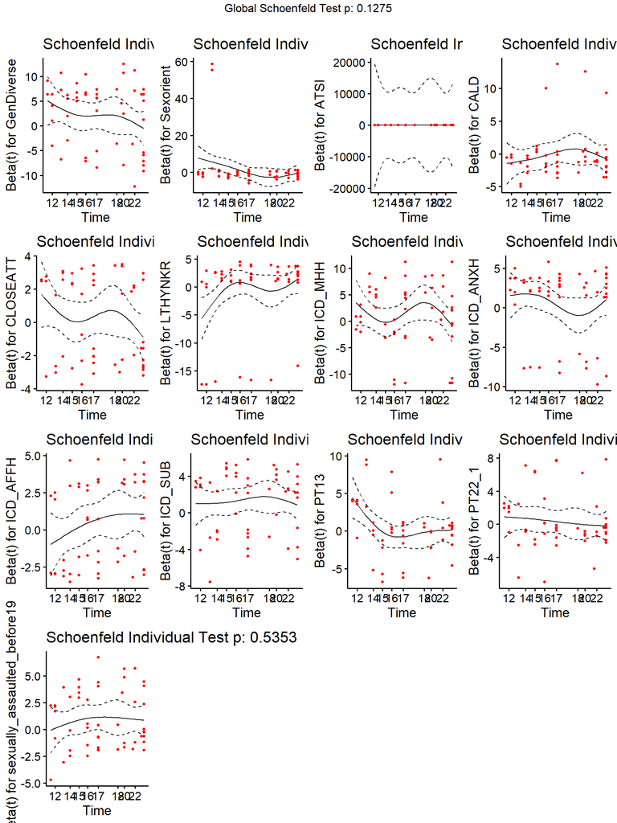

| variables | HR (95% CI) | p-value | exp(coef) | lower .95 | upper .95 |
| --- | --- | --- | --- | --- | --- |
| GenDiverseFemale | 1.51(0.73, 3.15) | 0.273 | 1.5143402 | 0.7280751 | 3.1497114 |
| GenDiverseGender diverse | 0.76(0.09, 6.49) | 0.803 | 0.7602292 | 0.0890740 | 6.4884078 |
| SexorientGay/Lesbian/Bisexual | 1.19(0.20, 6.91) | 0.851 | 1.1852378 | 0.2033023 | 6.9098524 |
| ATSIAboriginal or Torres Strait Islander | 0.00(0.00, 0.00) | <0.001 | 0.0000001 | 0.0000001 | 0.0000002 |
| CALDYes | 1.18(0.33, 4.23) | 0.796 | 1.1845152 | 0.3314383 | 4.2332956 |
| CLOSEATTYes | 0.99(0.38, 2.55) | 0.980 | 0.9878824 | 0.3833870 | 2.5454999 |
| LTHYNKRHas a long-term health condition | 1.30(0.48, 3.52) | 0.612 | 1.2973676 | 0.4776301 | 3.5239883 |
| ICD_MHHHas a lifetime mental disorder | 1.28(0.32, 5.20) | 0.727 | 1.2848031 | 0.3174469 | 5.1999845 |
| ICD_ANXHHas a lifetime Anxiety Disorder | 3.14(1.32, 7.48) | 0.013 | 3.1398688 | 1.3175936 | 7.4824102 |
| ICD_AFFHHas a lifetime Affective Disorder | 2.27(1.02, 5.05) | 0.050 | 2.2715313 | 1.0222037 | 5.0477755 |
| ICD_SUBHas a lifetime Substance Use Disorder | 4.81(2.06,11.22) | 0.001 | 4.8093637 | 2.0612446 | 11.2213656 |
| PT13Yes | 1.59(0.64, 3.95) | 0.327 | 1.5866203 | 0.6366552 | 3.9540460 |
| PT22_1Yes | 1.23(0.64, 2.37) | 0.533 | 1.2325123 | 0.6421835 | 2.3655025 |
| sexually_assaulted_before19Yes | 3.26(1.69, 6.26) | 0.001 | 3.2571415 | 1.6942752 | 6.2616575 |

[1] “Age first time self-harmed” [1] “16 to 25”

|  | chisq | df | p |
| --- | --- | --- | --- |
| GenDiverse | 3.0092637 | 2 | 0.2220990 |
| Sexorient | 0.3372361 | 1 | 0.5614289 |
| ATSI | 0.3256493 | 1 | 0.5682323 |
| CALD | 1.2786122 | 1 | 0.2581572 |
| CLOSEATT | 1.8779423 | 1 | 0.1705682 |
| LTHYNKR | 0.0449788 | 1 | 0.8320431 |
| ICD_MHH | 0.0520339 | 1 | 0.8195612 |
| ICD_ANXH | 0.0190504 | 1 | 0.8902220 |
| ICD_AFFH | 5.4466896 | 1 | 0.0196054 |
| ICD_SUB | 0.4643941 | 1 | 0.4955775 |
| PT13 | 0.2594082 | 1 | 0.6105270 |
| PT22_1 | 0.0338812 | 1 | 0.8539596 |
| sexually_assaulted_before19 | 1.3690120 | 1 | 0.2419817 |
| GLOBAL | 18.9198355 | 14 | 0.1680350 |

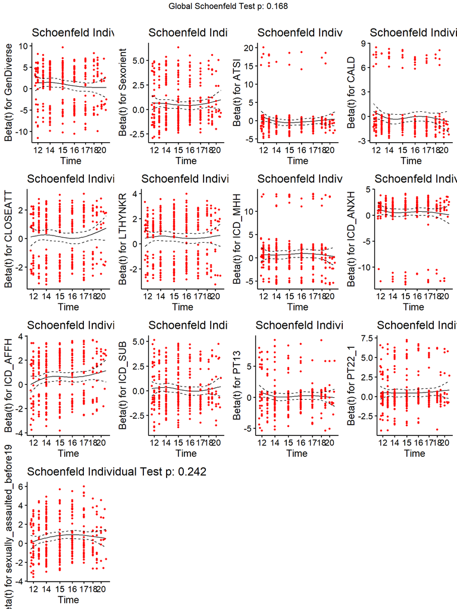

| variables | HR (95% CI) | p-value | exp(coef) | lower .95 | upper .95 |
| --- | --- | --- | --- | --- | --- |
| GenDiverseFemale | 1.45(1.11,1.89) | 0.007 | 1.4468769 | 1.1085912 | 1.888390 |
| GenDiverseGender diverse | 1.47(0.86,2.51) | 0.158 | 1.4707738 | 0.8618693 | 2.509865 |
| SexorientGay/Lesbian/Bisexual | 1.80(1.34,2.43) | <0.001 | 1.8025750 | 1.3385605 | 2.427441 |
| ATSIAboriginal or Torres Strait Islander | 0.88(0.50,1.55) | 0.658 | 0.8804502 | 0.5010973 | 1.546990 |
| CALDYes | 0.80(0.54,1.17) | 0.251 | 0.7973602 | 0.5418235 | 1.173414 |
| CLOSEATTYes | 1.30(1.01,1.66) | 0.041 | 1.2955872 | 1.0116789 | 1.659169 |
| LTHYNKRHas a long-term health condition | 1.70(1.30,2.23) | <0.001 | 1.7049661 | 1.3035428 | 2.230007 |
| ICD_MHHHas a lifetime mental disorder | 1.69(0.98,2.92) | 0.060 | 1.6927228 | 0.9799083 | 2.924060 |
| ICD_ANXHHas a lifetime Anxiety Disorder | 1.99(1.27,3.11) | 0.003 | 1.9876899 | 1.2702570 | 3.110324 |
| ICD_AFFHHas a lifetime Affective Disorder | 1.69(1.27,2.25) | <0.001 | 1.6935146 | 1.2723724 | 2.254051 |
| ICD_SUBHas a lifetime Substance Use Disorder | 1.12(0.85,1.48) | 0.428 | 1.1201579 | 0.8464548 | 1.482363 |
| PT13Yes | 1.49(1.00,2.22) | 0.048 | 1.4938138 | 1.0045434 | 2.221387 |
| PT22_1Yes | 1.57(1.14,2.17) | 0.006 | 1.5731023 | 1.1398387 | 2.171054 |
| sexually_assaulted_before19Yes | 1.75(1.32,2.32) | <0.001 | 1.7491912 | 1.3195900 | 2.318652 |

[1] “Age first time self-harmed” [1] “26 to 41”

|  | chisq | df | p |
| --- | --- | --- | --- |
| GenDiverse | 26.4958441 | 2 | 0.0000018 |
| Sexorient | 1.5272466 | 1 | 0.2165262 |
| ATSI | 1.0526479 | 1 | 0.3048980 |
| CALD | 1.9968702 | 1 | 0.1576244 |
| CLOSEATT | 6.9255215 | 1 | 0.0084974 |
| LTHYNKR | 0.0304147 | 1 | 0.8615527 |
| ICD_MHH | 0.1220267 | 1 | 0.7268467 |
| ICD_ANXH | 0.3961376 | 1 | 0.5290907 |
| ICD_AFFH | 2.0633322 | 1 | 0.1508799 |
| ICD_SUB | 4.3390108 | 1 | 0.0372486 |
| PT13 | 1.7919876 | 1 | 0.1806842 |
| PT22_1 | 1.6164238 | 1 | 0.2035912 |
| sexually_assaulted_before19 | 18.7006830 | 1 | 0.0000153 |
| GLOBAL | 49.3571325 | 14 | 0.0000078 |

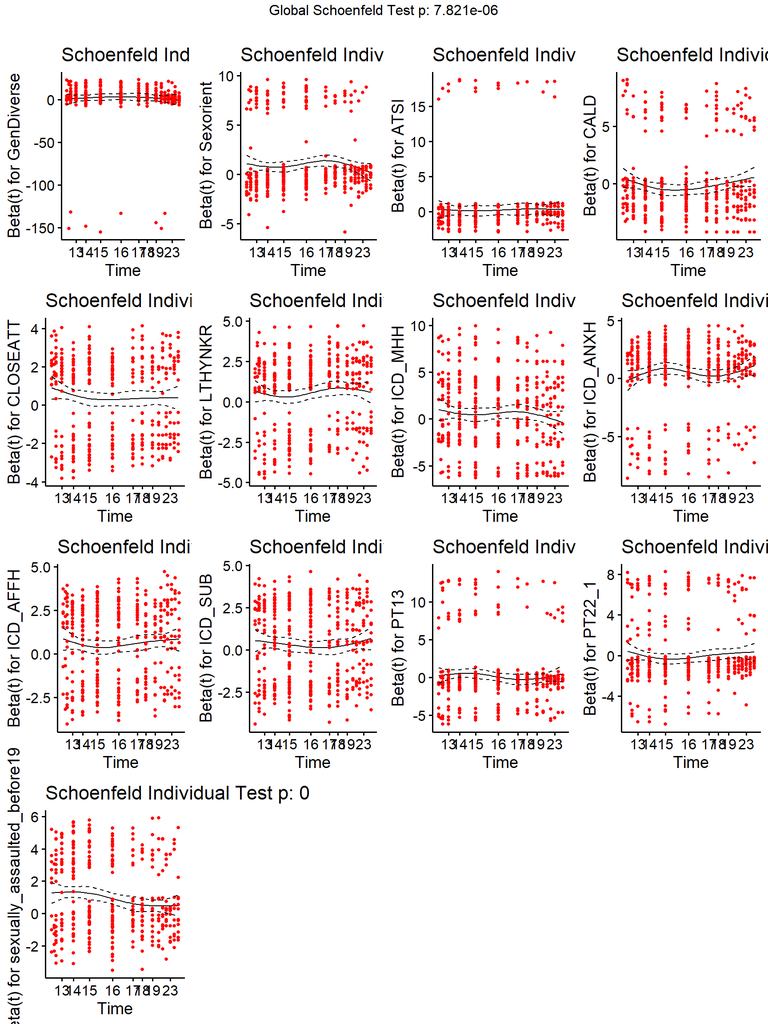

| variables | HR (95% CI) | p-value | exp(coef) | lower .95 | upper .95 |
| --- | --- | --- | --- | --- | --- |
| GenDiverseFemale | 1.01(0.79,1.29) | 0.934 | 1.0105492 | 0.7891071 | 1.294133 |
| GenDiverseGender diverse | 0.79(0.30,2.10) | 0.633 | 0.7874952 | 0.2956053 | 2.097894 |
| SexorientGay/Lesbian/Bisexual | 1.79(1.29,2.47) | 0.001 | 1.7869915 | 1.2907623 | 2.473994 |
| ATSIAboriginal or Torres Strait Islander | 1.68(0.92,3.06) | 0.092 | 1.6775477 | 0.9196561 | 3.060020 |
| CALDYes | 0.88(0.64,1.20) | 0.414 | 0.8761853 | 0.6382800 | 1.202765 |
| CLOSEATTYes | 1.56(1.22,2.01) | 0.001 | 1.5649285 | 1.2164477 | 2.013240 |
| LTHYNKRHas a long-term health condition | 1.64(1.26,2.13) | <0.001 | 1.6366252 | 1.2598168 | 2.126136 |
| ICD_MHHHas a lifetime mental disorder | 1.36(0.84,2.19) | 0.211 | 1.3581728 | 0.8410207 | 2.193327 |
| ICD_ANXHHas a lifetime Anxiety Disorder | 1.83(1.31,2.55) | <0.001 | 1.8274397 | 1.3082787 | 2.552618 |
| ICD_AFFHHas a lifetime Affective Disorder | 1.81(1.41,2.31) | <0.001 | 1.8083899 | 1.4132625 | 2.313989 |
| ICD_SUBHas a lifetime Substance Use Disorder | 1.84(1.43,2.38) | <0.001 | 1.8444978 | 1.4314171 | 2.376786 |
| PT13Yes | 1.13(0.77,1.67) | 0.527 | 1.1327624 | 0.7701332 | 1.666141 |
| PT22_1Yes | 0.97(0.71,1.32) | 0.842 | 0.9688780 | 0.7094410 | 1.323189 |
| sexually_assaulted_before19Yes | 2.60(1.99,3.41) | <0.001 | 2.6032665 | 1.9860570 | 3.412287 |

[1] “Age first time self-harmed” [1] “42 to 57”

|  | chisq | df | p |
| --- | --- | --- | --- |
| GenDiverse | 1.6298910 | 2 | 0.4426635 |
| Sexorient | 3.4600109 | 1 | 0.0628699 |
| ATSI | 0.0012812 | 1 | 0.9714465 |
| CALD | 10.8923500 | 1 | 0.0009656 |
| CLOSEATT | 0.0030720 | 1 | 0.9557991 |
| LTHYNKR | 5.5803767 | 1 | 0.0181628 |
| ICD_MHH | 0.0010488 | 1 | 0.9741649 |
| ICD_ANXH | 0.0336457 | 1 | 0.8544625 |
| ICD_AFFH | 2.1701947 | 1 | 0.1407084 |
| ICD_SUB | 0.1206865 | 1 | 0.7282912 |
| PT13 | 7.2895121 | 1 | 0.0069358 |
| PT22_1 | 0.6035487 | 1 | 0.4372272 |
| sexually_assaulted_before19 | 6.2544558 | 1 | 0.0123881 |
| GLOBAL | 34.9516767 | 14 | 0.0014944 |

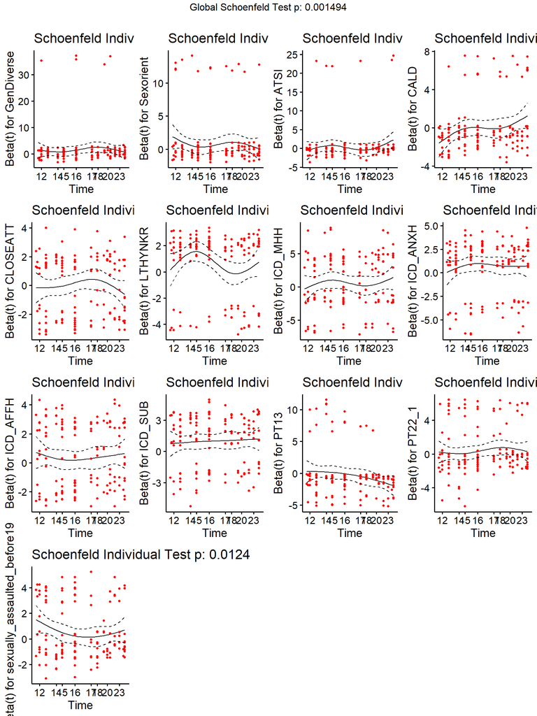

| variables | HR (95% CI) | p-value | exp(coef) | lower .95 | upper .95 |
| --- | --- | --- | --- | --- | --- |
| GenDiverseFemale | 1.07(0.68,1.69) | 0.762 | 1.0729510 | 0.6804536 | 1.691848 |
| GenDiverseGender diverse | 2.87(1.06,7.80) | 0.041 | 2.8714721 | 1.0567437 | 7.802604 |
| SexorientGay/Lesbian/Bisexual | 1.94(0.93,4.05) | 0.079 | 1.9435937 | 0.9316111 | 4.054864 |
| ATSIAboriginal or Torres Strait Islander | 1.70(0.60,4.85) | 0.323 | 1.6990256 | 0.5955441 | 4.847144 |
| CALDYes | 1.06(0.59,1.91) | 0.855 | 1.0568376 | 0.5857201 | 1.906893 |
| CLOSEATTYes | 1.20(0.78,1.84) | 0.398 | 1.2029119 | 0.7847108 | 1.843988 |
| LTHYNKRHas a long-term health condition | 2.20(1.34,3.59) | 0.002 | 2.1957322 | 1.3429936 | 3.589920 |
| ICD_MHHHas a lifetime mental disorder | 1.42(0.59,3.42) | 0.434 | 1.4211409 | 0.5909577 | 3.417574 |
| ICD_ANXHHas a lifetime Anxiety Disorder | 2.32(1.30,4.14) | 0.005 | 2.3175248 | 1.2976632 | 4.138918 |
| ICD_AFFHHas a lifetime Affective Disorder | 1.62(1.03,2.55) | 0.038 | 1.6230628 | 1.0311335 | 2.554793 |
| ICD_SUBHas a lifetime Substance Use Disorder | 2.85(1.72,4.72) | <0.001 | 2.8491553 | 1.7200850 | 4.719352 |
| PT13Yes | 0.68(0.30,1.53) | 0.350 | 0.6770104 | 0.2993995 | 1.530875 |
| PT22_1Yes | 1.39(0.75,2.58) | 0.298 | 1.3900891 | 0.7489847 | 2.579956 |
| sexually_assaulted_before19Yes | 2.01(1.25,3.25) | 0.005 | 2.0134957 | 1.2481170 | 3.248225 |

```r
write.csv(store.results, "cox_results.csv", row.names = FALSE)
```